# cnefetools: Access and Analysis of Brazilian CNEFE Address Data in R

The cnefetools package provides programmatic access to the Brazilian National Address File for Statistical Purposes (CNEFE), a geocoded register from the 2022 census, published by the Instituto Brasileiro de Geografia e Estatística (IBGE), with 111.1 million records, one for each type of use found at an address. Although the CNEFE enables fine-grained spatial analyses central to urban and regional planning, such as characterising land use patterns and redistributing census aggregates to arbitrary spatial zones, leveraging it requires overcoming both access barriers, arising from its distribution across thousands of municipality-level files with no unified programmatic interface, and computational barriers from spatial operations that scale to millions of records. cnefetools addresses both through four capabilities: (i) downloading and caching CNEFE data for any of Brazil’s 5,570 municipalities; (ii) aggregating address counts to H3 hexagonal grids or user-supplied polygons; (iii) computing land use mix indices; and (iv) performing dasymetric interpolation of census tract variables to arbitrary spatial units using CNEFE dwelling points as ancillary data. The package provides a flexible dual-backend architecture for all computationally intensive operations. The default DuckDB backend reads the cached data in-process and handles all spatial joins, H3 indexing, and aggregations without transferring intermediate results to R, with an advantage that grows with dataset size and exceeds fifteenfold on São Paulo, the largest municipality in the country, where its peak memory is also more than twelve times smaller than the pure-R fallback’s.

Jorge Ubirajara Pedreira Junior https://pedreirajr.github.io/website/ (Universidade Federal da Bahia) , Bruno Henrique Mioto Stabile (Universidade Estadual de Maringá)  
2026-10-01

## 1 Introduction

Address-level data are a fundamental resource for urban and regional analysis. They enable fine-grained characterisation of land use, population distribution, and the spatial organisation of economic and social activities. Unlike parcel boundaries or building footprints, which often require proprietary sources, geocoded address registers are administrative by-products of census enumeration, making them publicly available in several countries.

Brazil is home to the fifth-largest population in the world, with approximately 213 million inhabitants spread across 5,570 municipalities (Instituto Brasileiro de Geografia e Estatística 2026). Since the 2010 Brazilian Census, the *Instituto Brasileiro de Geografia e Estatística* (IBGE) has produced a rich by-product: the *Cadastro Nacional de Endereços para Fins Estatísticos* (CNEFE, National Address File for Statistical Purposes). This dataset records the geocoordinates and functional category of addresses across the entire country, in 111.1 million records.

Despite its potential, the CNEFE presents significant barriers to use. The data are distributed as individual ZIP-compressed CSV files (one per municipality or state) via the IBGE FTP server. Municipal files can reach 177 MB compressed (901 MB uncompressed), as in the case of São Paulo, which contains approximately 5.7 million point addresses. Spatial operations on these files (assigning points to grid cells, computing land use mix, or matching them to census tract polygons) require substantial data engineering. As a result, researchers who could benefit from this dataset are often unable to leverage it without considerable ad-hoc effort.

The cnefetools package addresses this gap. It provides a unified interface for downloading, caching, and analysing CNEFE data directly from R, with four principal capabilities:

1. **Data access**: download and read CNEFE data for any municipality, with transparent caching to avoid repeated downloads.
2. **Address counts**: aggregate address points to H3 hexagonal grids (Uber’s open-source hierarchical geospatial indexing system) or user-supplied polygons, returning counts by address type.
3. **Land use mix indices**: compute a suite of established and novel land use mix (LUM) indices.
4. **Dasymetric interpolation**: redistribute census tract aggregates to any spatial unit using CNEFE dwelling points as ancillary data.

For the interpolation task, a few packages exist for this purpose, but with limitations worth noting. Areal-weighted approaches, such as those provided by sf (Pebesma 2018) and areal (Prener and Revord 2019), assume a uniform distribution of the attribute within each source zone, which is methodologically weaker than dasymetric methods that incorporate ancillary data on where people actually live. populR (Batsaris and Kavroudakis 2023) takes a dasymetric approach using building footprints as ancillary data. Its volume-weighting mode additionally incorporates building height or floor counts, but these remain imperfect proxies: two buildings of equal height may house very different numbers of households depending on floor plan and unit size, and height or floor data from volunteered geographic information are frequently incomplete.

Because each private household record in the CNEFE is one dwelling, the count of such points within a zone directly reflects the number of dwellings, making it a more precise ancillary variable for identifying population density in verticalized urban environments. Beyond interpolation, no R package currently provides tools for computing land use mix indices from either address-level or polygon-based data.

A key technical contribution is a dual-backend architecture. The default DuckDB backend (Raasveldt and Mühleisen 2019), supported by the duckdb R package, reads the cached gzipped CSV directly, without prior extraction and without any third-party extension, performs H3 cell assignment and spatial joins entirely in-process, and returns only the final aggregated result to R. Measured against a pure-R fallback based on h3jsr (Hamilton 2023) and sf (Pebesma 2018), its advantage grows with dataset size and exceeds fifteenfold on São Paulo, where its peak memory is also more than twelve times smaller (see Section 5 for benchmarks).

This paper is organised as follows. Section 2 describes the CNEFE dataset and its distribution. Section 3 presents the architectural decisions underpinning cnefetools. Section 4 describes each exported function in detail. Section 5 reports performance benchmarks. Section 6 summarises contributions and discusses future directions.

## 2 The CNEFE dataset

The *Cadastro Nacional de Endereços para Fins Estatísticos* (CNEFE) is the geocoded address register produced alongside the Brazilian Census. Its production process began in 2005, and it was designed to serve statistical (rather than postal) purposes, recording not only residences but also non-residential address points including commercial establishments, agricultural units, schools, health facilities, and religious temples (Instituto Brasileiro de Geografia e Estatística 2024). The first CNEFE was published alongside the 2010 census, though the precision achieved at that time was limited to the block-face level (Instituto Brasileiro de Geografia e Estatística 2024). cnefetools therefore targets the 2022 edition and future censuses, as 2022 is the first to provide address-level geocoordinates for the full national register.

During the 2022 census, coordinates were collected by enumerators equipped with mobile devices integrating GNSS receivers. Each device was preloaded with a list of addresses for the assigned census tract and up to three GNSS readings were required before the enumerator could classify an address by functional type. After field collection, IBGE applied an extensive post-processing workflow: invalid or missing coordinates were estimated from block-face geometry, confirmed nearby addresses, or the enumerator’s recorded position at the time of interview. Quality levels were classified by geocoding resolution: address, block face, locality, or census tract. Pre-census testing measured mean squared error (MSE) of 5.84 m, with maximum error below 11.71 m under ideal open-sky conditions and typical collection environments (Instituto Brasileiro de Geografia e Estatística 2024).

### 2.1 Structure, scale and distribution

Each CNEFE record corresponds to one type of use at an address, which IBGE calls an address species, so an address that hosts more than one use appears as more than one record and the number of records exceeds the number of addresses (Instituto Brasileiro de Geografia e Estatística 2024). In the rest of this paper, *address* refers to a CNEFE record. The dataset uses a fixed schema of 34 columns. The most analytically relevant columns are:

- **`LONGITUDE`** and **`LATITUDE`**: geographic coordinates in the SIRGAS 2000 datum (EPSG:4674, approximately equivalent to WGS 84 for most applications).
- **`COD_ESPECIE`**: an integer code (1–8) identifying the functional category of the address, referred to in this paper as the *address type*. The eight categories are listed in Table 1.
- Address description fields, including street type (**`NOM_TIPO_SEGLOGR`**), street name (**`NOM_SEGLOGR`**), address number (**`NUM_ENDERECO`**), free-text address description (**`DSC_ESTABELECIMENTO`**), and postal code (**`CEP`**).

Table 1: CNEFE address types (`COD_ESPECIE`).

| Code | English label | Portuguese label |
| --- | --- | --- |
| 1 | Private household | Domicílio particular |
| 2 | Collective household | Domicílio coletivo |
| 3 | Agricultural establishment | Estabelecimento agropecuário |
| 4 | Educational establishment | Estabelecimento de ensino |
| 5 | Health establishment | Estabelecimento de saúde |
| 6 | Other establishment | Estabelecimento de outras finalidades |
| 7 | Under construction | Edificação em construção ou reforma |
| 8 | Religious establishment | Estabelecimento religioso |

The CNEFE covers all 5,570 Brazilian municipalities, with address counts ranging from a few hundred in small rural municipalities to approximately 5.7 million in São Paulo, the most populous city in the Southern Hemisphere. The consolidated dataset comprises 111.1 million geographic records, of which 98.95% were validated as spatially coherent. More than 110.7 million records (99.68%) were geocoded at the address level: 93.8% from original field coordinates, 5.5% with standardised corrections (e.g., apartment units sharing the same street number), and 0.7% estimated via spatial interpolation.

Within the universe of constructed addresses, private dwellings (address type 1) are the most numerous, comprising approximately 90.6 million records (81.5% of the total). Collective households (address type 2) account for roughly 104,500 records (0.1%). Among non-residential types, other-purpose establishments (address type 6) number approximately 11.7 million (10.5%), followed by agricultural establishments (address type 3) at 4.1 million (3.7%), while educational (address type 4), health (address type 5), and religious establishments (address type 8) jointly account for approximately 1.1 million records (1.0%). Buildings under construction (address type 7) numbered approximately 3.5 million (3.2%).

The data are distributed by IBGE via an FTP server at https://ftp.ibge.gov.br/Cadastro_Nacional_de_Enderecos_para_Fins_Estatisticos/. Files are organised hierarchically by Federative Unit/state (UF) and municipality. Each municipality’s data are stored as a semicolon-delimited CSV file compressed inside a ZIP archive.

### 2.2 Challenges for programmatic use

Working with the CNEFE presents several practical difficulties that cnefetools is designed to overcome:

- **Discovery**: there is no unified index of download URLs. Constructing the correct URL requires knowledge of the state acronym, the full municipality name as it appears in the FTP directory (which does not always match standard IBGE name fields), and the municipality code.
- **Download size**: while most files are modest, the largest cities produce ZIP files running into the hundreds of megabytes.
- **Spatial operations at scale**: assigning millions of point coordinates to hexagonal cells or performing point-in-polygon joins with census tract geometries is computationally intensive in pure R.

## 3 Package design

cnefetools addresses the challenges above through three key design decisions: a pre-built URL index, a persistent user-level cache, and a dual DuckDB/R backend. The analytical functions — `cnefe_counts()`, `compute_lumi()`, `tracts_to_h3()`, and `tracts_to_polygon()` — each follow a common two-phase workflow: retrieving the CNEFE data for the requested municipality (by downloading the ZIP from the IBGE FTP server, or reading it from a local cache on subsequent calls), and then performing the requested computation over potentially millions of address records. `read_cnefe()` covers only the first phase, returning the raw CNEFE table or a spatial object without further aggregation. Because every function handles retrieval internally, users call whichever function fits their need directly, without a separate data-loading step. All user-facing functions additionally validate their inputs with checkmate (Lang 2017) before any I/O (normalizing municipality codes, verifying geometry types, and repairing invalid geometries), so errors are caught before any network or disk operation begins. Every function works on one municipality at a time, and Section 6 discusses how analyses that span several municipalities can be carried out today.

### 3.1 Pre-built municipality index

The package ships with an internal data frame (`cnefe_index`) that maps each of Brazil’s 5,570 seven-digit IBGE municipality codes to its corresponding CNEFE ZIP download URL. This index was constructed from the FTP directory listing at the time of package release. The index also records the municipality name and the UF, enabling informative error messages when an unrecognised code is provided. Municipality codes are validated and normalized by an internal helper, which accepts integer, character, and numeric inputs and checks that the code is a seven-digit IBGE code present in the index.

Because the index is fixed when the package is released, it does not follow later changes to the FTP layout. Before downloading, the package therefore checks whether the server can be reached and whether the file exists. An unreachable server points the user to their connection. When the file is missing, the package lists the published directory, where file names start with the municipality code, and retries with the URL it finds there. Only if that also fails does it report that the layout has changed upstream and ask the user to report it. Either way, a ZIP obtained by other means can still be read with `read_cnefe(file = ...)`, described below.

### 3.2 Persistent user-level caching

Because CNEFE files can be as large as 177 MB compressed for São Paulo, repeated downloads would impose a substantial cost on iterative workflows. cnefetools therefore caches each municipality locally on first download, creating the cache directory on first use and persisting it across R sessions.

What is cached is a gzipped CSV rather than the ZIP as published. The conversion runs once, on first download, streamed in chunks so that peak memory does not scale with the file, and written through a temporary name so that an interrupted run cannot leave behind something that later passes for a valid cache entry. Gzip was chosen over raw CSV because it costs essentially nothing on disk relative to the published ZIP, whereas the uncompressed CSV is several times larger, and because DuckDB decompresses it natively, which keeps the read path free of any third-party extension.

The cache location resolves from the most specific source to the least: the `cache_dir` argument of the calling function, then the `CNEFETOOLS_CACHE_DIR` environment variable, and finally `tools::R_user_dir("cnefetools", "cache")`, which remains the default so that users who do nothing see the previous behaviour. Both mechanisms are offered deliberately, since an environment variable suits a machine configured once while an explicit argument lets a single call be redirected without touching the session. The argument is accepted by every function that reads data, and also by `clear_cache_muni()` and `clear_cache_tracts()`, because a redirected cache the cleaners could not see would report success while deleting nothing.

Download integrity is verified by checking that the downloaded file is a valid ZIP archive and that it contains a CSV file matching the expected naming pattern. Corrupted or incomplete downloads are detected and retried with increasing timeout thresholds (300 s, 600 s, and 1,800 s). Caching can be disabled with `cache = FALSE`, in which case the data is written to a temporary file and removed when the function exits. Users also have direct control over the local cache: `clear_cache_muni()` and `clear_cache_tracts()` allow selectively removing cached files, either all at once or filtered by municipality or state (see Section 4.5).

For workflows that need the data outside this transient cache, `cnefe_export()` writes a permanent copy to a location of the user’s choosing, and the `file` argument of `read_cnefe()` reads such a copy back without any download (see Section 4.5). Together they let a user keep an optimised copy on whichever disk suits them, and they also make ingestion independent of the download path, which matters if access to the upstream server ever changes.

### 3.3 Dual-backend architecture

For the computationally intensive operations in `cnefe_counts()` and `compute_lumi()`, such as assigning millions of coordinates to H3 hexagons or user-supplied polygons and performing spatial joins, users can choose between two backends via the `backend` argument:

- **`"duckdb"` (default)**: uses the duckdb (Mühleisen and Raasveldt 2024) R package alongside some DuckDB extensions to spin up an in-memory DuckDB database. Reading the cached gzipped CSV requires no extension at all, since DuckDB decompresses gzip natively. For H3 aggregation, the `h3` extension assigns cell indices entirely in SQL, while for user-provided polygons, the `spatial` extension and the duckspatial R package (Cidre González et al. 2026) handle the point-in-polygon join. Only the final aggregated result is transferred to R. The `zipfs` extension is still available but is loaded on demand, only when the file at hand is actually a ZIP, which now happens solely for a cache written by an earlier version or for a file the user supplies directly.
- **`"r"`**: for H3 aggregation, h3jsr assigns each point to a cell, whereas for user-provided polygons, sf performs the point-in-polygon join. This backend is slower but requires no DuckDB dependency whatsoever.

The dasymetric interpolation functions `tracts_to_h3()` and `tracts_to_polygon()` do not expose this argument and rely on DuckDB exclusively by design, because their cost is dominated by a point-in-polygon overlay between every dwelling point in the municipality and the census tract polygons, which is a different and heavier workload than the tabular aggregation that the pure-R backend handles, and it is the step that benefits most from DuckDB’s spatial index (Section 4.4).

The census tract geometry assets required by `tracts_to_h3()` and `tracts_to_polygon()` are stored as Parquet files (one per UF, each containing a `geom_wkb` column with the geometries of census tract polygons encoded in Well-Known Binary) and published as assets on the package’s GitHub Releases page. They are downloaded on-demand with caching via the piggyback package (Boettiger and Ho 2023).

### 3.4 Data provenance

Besides the CNEFE files, which are downloaded from IBGE as published, the package depends on two data products of its own, the municipality index and the census tract assets. The scripts that build both are in the `data-raw/` directory of the package repository, so either can be rebuilt or audited.

The index is built by `data-raw/cnefe_index_2022.R`, which takes the list of 2022 municipalities from geobr and the file names from the directory listing of each state on the IBGE FTP server.

The census tract assets are built by `data-raw/sc_assets_build.R`. Tract geometries come from geobr, and tract attributes come from censobr (Pereira and Barbosa 2026), which repackages the IBGE census tract aggregates, so the variable codes listed in Table 3 are those used by censobr. Some tracts are returned by geobr as several rows, one for each disjoint part, and the script dissolves them into a single geometry per tract, since otherwise the dwelling points of such a tract would be counted once for each part. The assets for the 2022 edition are served from the release tag `sc-assets-v3`, which was built with this script, and a tract-by-tract comparison with the files originally published with the package found the same 468,097 tracts in all 27 states and identical values in all 3,144,868 comparisons. The SHA-256 checksum and size of each file are recorded in `data-raw/sc_assets_checksums.csv`, so a user can confirm that a downloaded file is the one that was published.

## 4 Core functionality

The following subsections document each function’s interface and illustrate its use with worked examples. All code examples use address data for the municipality of Lauro de Freitas, Bahia (IBGE code 2919207).

### 4.1 Reading CNEFE data: `read_cnefe()`

`read_cnefe()` is the entry point to the package. It downloads (if not cached) and reads the CNEFE CSV for a municipality, returning either an arrow (Richardson et al. 2026) `Table` or an sf point object. The code below illustrates both output modes for Lauro de Freitas.

```r
library(cnefetools)

# Read as an Arrow table (default; no spatial conversion)
cnefe <- read_cnefe(
  code_muni = 2919207,
  year      = 2022,
  cache     = TRUE,
  verbose   = TRUE,
  output    = 'arrow'    # default
)

# Read as an sf point object with SIRGAS 2000 coordinates (EPSG:4674)
cnefe_sf <- read_cnefe(
  code_muni = 2919207,
  year      = 2022,
  cache     = TRUE,
  verbose   = TRUE,
  output    = 'sf'
)
```

The `output = "arrow"` default (an `arrow::Table`) is preferred for large municipalities because it avoids materialising the full data frame in memory. The table can be filtered and projected using dplyr verbs applied to Arrow tables before conversion to a data frame. The `output = "sf"` option converts the Arrow table to a data frame, coerces `LONGITUDE` and `LATITUDE` to numeric, drops rows with missing coordinates, and constructs an `sf` point object in CRS 4674 (SIRGAS 2000).

The code below previews seven selected columns for the first six records of the dataset previously read as an `arrow::Table`.

```r
library(dplyr)

cnefe |>
  select(NOM_TIPO_SEGLOGR, NOM_SEGLOGR, CEP, COD_ESPECIE,
         LONGITUDE, LATITUDE, DSC_ESTABELECIMENTO) |>
  collect() |>
  head()
```

```
#> # A tibble: 6 × 7
#>   NOM_TIPO_SEGLOGR NOM_SEGLOGR      CEP COD_ESPECIE LONGITUDE LATITUDE
#>   <chr>            <chr>          <int>       <int>     <dbl>    <dbl>
#> 1 CAMINHO          31A           4.27e7           6     -38.3    -12.9
#> 2 RUA              ANILTON DA C… 4.27e7           1     -38.3    -12.9
#> 3 RUA              ANILTON DA C… 4.27e7           7     -38.3    -12.9
#> 4 TRAVESSA         SEM DENOMINA… 4.27e7           1     -38.3    -12.9
#> 5 RUA              DO CARMO      4.27e7           1     -38.4    -12.9
#> 6 RUA              DO CARMO      4.27e7           1     -38.3    -12.9
#> # ℹ 1 more variable: DSC_ESTABELECIMENTO <chr>
```

The function accepts the `year` argument (currently only 2022 is supported), `cache` to control caching, and `verbose` to toggle informative progress messages. Figure 1 maps the educational establishment addresses for Lauro de Freitas which was previously read in `cnefe_sf`.

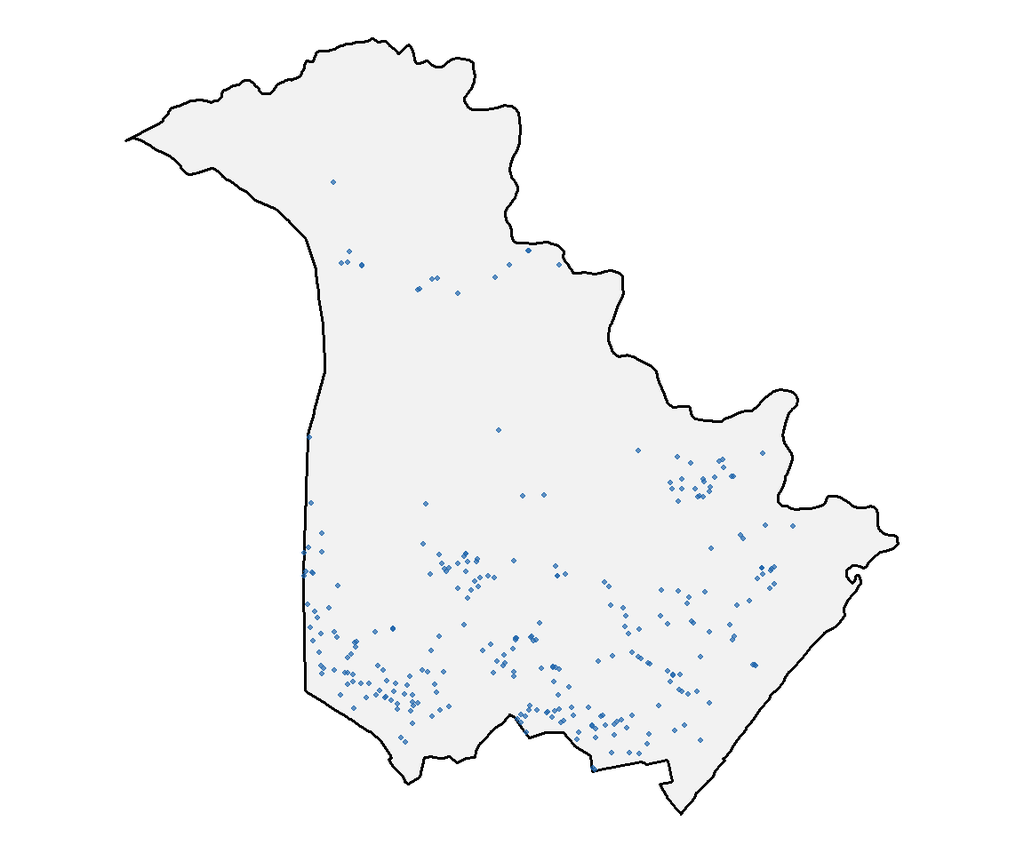

Figure 1: Educational establishment addresses geocoded in Lauro de Freitas, Bahia.

### 4.2 Address counts on spatial units: `cnefe_counts()`

`cnefe_counts()` aggregates CNEFE address points to areal spatial units and returns counts of each address type (1 through 8) as columns `addr_type1` to `addr_type8`. To illustrate both output modes, the examples below count addresses per H3 hexagon at resolution 9 and per official neighborhood boundary obtained from geobr (Pereira et al. 2019).

```r
# Count addresses per H3 hexagon at resolution 9
hex_counts <- cnefe_counts(
  code_muni     = 2919207,
  year          = 2022,
  cache         = TRUE,
  h3_resolution = 9,
  verbose       = TRUE,
  backend       = "duckdb"
)

# Count per user-supplied polygon (e.g., neighborhoods)
library(geobr)
library(dplyr)

nei <- read_neighborhood(year = 2022) |>
  filter(code_muni == 2919207)

poly_counts <- cnefe_counts(
  code_muni    = 2919207,
  year         = 2022,
  cache        = TRUE,
  polygon      = nei,
  crs_output   = NULL,
  verbose      = TRUE,
  backend      = "duckdb"
)
```

When no `polygon` is supplied (the default), the function builds a complete H3 grid over the municipality boundary using geobr to obtain the boundary polygon and h3jsr to generate the hexagon geometries. The DuckDB `h3` extension is used (when `backend = "duckdb"`) to assign CNEFE points to cells in SQL, but the grid itself is always constructed via h3jsr. The H3 resolution can be set from 0 (coarse) to 15 (fine), and the default is 9, corresponding to an average hexagon area of approximately 105,000 m².

That figure is an average, because H3 is not an equal-area grid. Cells are laid out on an icosahedron projected onto the globe, so cells of the same resolution differ in area depending on where they fall. Across Brazil, resolution 9 cells range from about 80,000 m² to 127,000 m², so the largest is about 1.6 times the smallest. This matters whenever an analysis assumes cells of equal size, as in density estimates. When equal area is a requirement, an equal-area grid is the better choice, such as the A5 grid available in a5R (Graham 2026) or IGEO7, which is built on the ISEA projection (Kmoch et al. 2025). cnefetools uses H3 because the DuckDB `h3` extension assigns cells inside the query, which keeps the aggregation in-process, and because H3 cell identifiers can be joined with other data indexed on the same grid.

When a `polygon` is supplied, the function performs a point-in-polygon join between the CNEFE coordinates and the user-supplied `sf` polygon. A warning is issued if any CNEFE points fall outside the polygon, together with the coverage percentage, and an error is raised if no points fall inside.

The output `sf` object inherits the polygon geometry: H3 hexagons when `polygon` is `NULL`, or the user-supplied polygons (in their original CRS, or `crs_output` if specified) when one is given. Figure 2 illustrates both modes for Lauro de Freitas at H3 resolution 8 and at the neighborhood level.

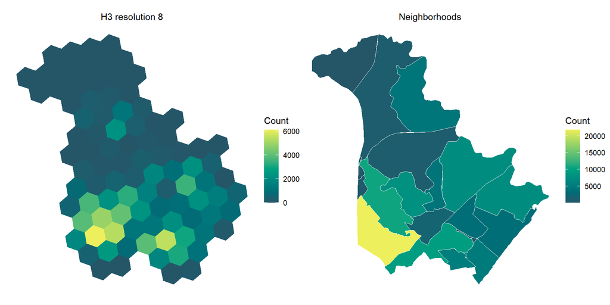

Figure 2: Private household address counts (`addr_type1`) aggregated to H3 hexagons at resolution~8 (left) and to neighborhoods (right) for Lauro de Freitas, Bahia.

### 4.3 Land use mix indices: `compute_lumi()`

`compute_lumi()` computes a suite of six land use mix (LUM) indices from CNEFE address data, providing the first R implementation of this class of spatial indicators. No other CRAN package implements land use mix indices, whether from address-level or polygon-based data. All indices are based on the local residential share $p_i = n_{\text{res},i} / n_{\text{tot},i}$, where $n_{\text{res},i}$ is the count of type-1 addresses (private households) and $n_{\text{tot},i}$ is the total count of addresses of all types except type 7 (under construction). The citywide residential share $P$ is computed in the same way over the whole municipality, and it is used by the Balance Index and by the BGBI.

Table 2 summarises the six indices computed by `compute_lumi()`, together with the residential share $p_i$ on which they are based, which is also returned. Further methodological details on these indices can be found in Song et al. (2013), Massey (2001), Pedreira Junior et al. (2025) and Pedreira Junior et al. (2026).

Table 2: Land use mix indices returned by `compute_lumi()`. Here $q_i = 1 - p_i$ and $r = P/(1-P)$.

| Index | Code | Formula | Range |
| --- | --- | --- | --- |
| Residential share | `p_res` | $p_i$ | $[0,1]$ |
| Entropy Index | `ei` | $-\,(p_i \ln p_i + q_i \ln q_i)\,/\ln 2$ | $[0,1]$ |
| Herfindahl-Hirschman Index | `hhi` | $p_i^2 + q_i^2$ | $[0.5,\,1]$ |
| Balance Index | `bal` | $1 - \lvert p_i - r\,q_i\rvert\,/\,(p_i + r\,q_i)$ | $[0,1]$ |
| Index of Concentration at Extremes | `ice` | $p_i - q_i$ | $[-1,+1]$ |
| Adapted HHI | `hhi_adp` | $\mathrm{sign}(p_i - q_i)\cdot(\mathrm{HHI}_i - 0.5)\,/\,0.5$ | $[-1,+1]$ |
| BGBI | `bgbi` | $[(2p_i-1)-(2P-1)]\,/\,[1-(2p_i-1)(2P-1)]$ | $[-1,+1]$ |

All the indices therefore rest on a binary split, in which an address counts as residential only when it is a private household (type 1) and as non-residential otherwise. They measure the balance between housing and all other uses, not the diversity of those other uses, so an area whose non-residential addresses are all of one type scores the same as an area where they are spread across every type, provided both have the same residential share. This is the formulation on which the indices were defined and validated against job accessibility in Pedreira Junior et al. (2026), but it differs from the multi-category definitions of land use mix that are common in urban research (Song et al. 2013). Users who need the diversity of non-residential uses can compute it from the counts by address type that `cnefe_counts()` returns.

Type 7 addresses are left out because a building under construction or renovation describes a transitional state rather than a realised use. Such buildings are likely to be concentrated where a city is expanding, so leaving them out makes the indices describe those areas as they are now rather than as they will be once the buildings are occupied. If these buildings end up in the same proportions as existing addresses, among which private households are the large majority, the indices understate the residential share those areas are heading towards, and the effect is largest where type 7 makes up a large share of addresses. `cnefe_counts()` does not apply this exclusion and reports these addresses as `addr_type7`, so users can check how many there are in any area of interest.

Because $P$ is computed from counts of address types, it describes how addresses are distributed across types in the municipality, not how residents are distributed. It is also always computed over the whole municipality, including when `polygon` is supplied, because it is meant to describe the city that the addresses belong to. A baseline computed only over the area covered by the polygons would measure mix relative to that area rather than relative to the city, which is a different quantity.

The parameter interface of `compute_lumi()` mirrors that of `cnefe_counts()`:

```r
# Compute all indices on H3 hexagons at resolution 9 (default)
lumi_hex <- compute_lumi(
  code_muni     = 2919207,
  year          = 2022,
  cache         = TRUE,
  h3_resolution = 9,
  verbose       = TRUE,
  backend       = "duckdb"
)

# Compute on user-supplied polygons
lumi_poly <- compute_lumi(
  code_muni    = 2919207,
  year         = 2022,
  cache        = TRUE,
  polygon      = nei,
  crs_output   = NULL,
  verbose      = TRUE,
  backend      = "duckdb"
)
```

The output `sf` object contains columns `id_hex` (or the original polygon columns), `p_res`, `ei`, `hhi`, `bal`, `ice`, `hhi_adp`, `bgbi`, and the polygon geometry. Figure 3 maps the BGBI index (Pedreira Junior et al. 2026) for Lauro de Freitas at H3 resolution 8 and at the neighborhood level.

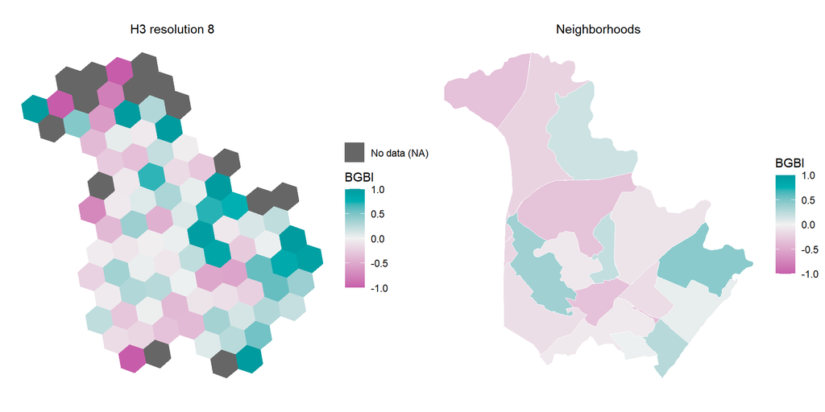

Figure 3: Bidirectional Global-centered Balance Index (BGBI) for Lauro de Freitas, Bahia, aggregated to H3 hexagons at resolution~8 (left) and to neighborhoods (right). Green cells indicate a local residential share above the citywide average ($p_i > P$); pink cells indicate non-residential dominance ($p_i < P$); white cells are near the citywide baseline.

Figure 3 illustrates how the spatial pattern of the BGBI can differ markedly between the H3 hexagonal grid and neighborhood boundaries: some neighborhoods aggregate areas of contrasting land use, smoothing out local variation that remains visible at the hexagon level, while the coarser polygon boundaries may shift which zones appear residentially dominant or non-residential. By allowing the same indices to be computed across multiple H3 resolutions and over user-supplied polygon layers, cnefetools makes it straightforward to assess the sensitivity of land use mix measurement to spatial aggregation and, therefore, to explicitly probe scale effects associated with the Modifiable Areal Unit Problem (MAUP) (Dark and Bram 2007).

### 4.4 Dasymetric interpolation: `tracts_to_h3()` and `tracts_to_polygon()`

The 2022 Brazilian Census disseminates questionnaire results through multiple geographic products, one of which is the *Agregados por Setores Censitários* (aggregates by census tract). A census tract (*setor censitário*) is the basic territorial unit of census collection and of this particular dissemination product. For many applications, however, the desired spatial unit differs from census tracts, as researchers may want data on a regular H3 grid for comparative analyses, or on custom polygons such as traffic zones for transportation modelling or health districts for public health management. For this purpose, cnefetools addresses this need with `tracts_to_h3()` and `tracts_to_polygon()`, which perform dasymetric interpolation (Mennis 2003) from census tract aggregates to user-defined spatial units using CNEFE dwelling points as ancillary data.

Several R packages tackle this polygon-to-polygon transfer problem using areal weighting. sf (Pebesma 2018), through `st_interpolate_aw()`, and areal (Prener and Revord 2019), through `aw_interpolate()`, both distribute source-zone totals in proportion to the overlap area between source and target polygons, implicitly assuming a uniform spatial distribution of the attribute within each source zone.

smile (da Cunha Godoy 2025) addresses the same change-of-support problem through a model-based approach. Source-zone values are treated as spatial averages of a latent Gaussian random field, `fit_spm()` estimates the field parameters from the source data, and `predict_spm()` aggregates predicted field values over target polygons or point locations, returning point estimates alongside prediction uncertainty. The redistribution is driven entirely by the modelled spatial correlation structure and no ancillary data are used.

populR (Batsaris and Kavroudakis 2023) is the closest in spirit to cnefetools. The `pp_estimate()` function supports both areal weighting and a dasymetric mapping that uses building footprints as ancillary data, weighting the redistribution by an estimate of building volume (derived from footprint area multiplied by building height or floor count) rather than by plain overlap area. Building polygons must be supplied by the user from any available source. `pp_compare()` additionally facilitates accuracy assessment against reference counts.

cnefetools follows the same dasymetric logic as the volume-weighting mode of populR, but uses geocoded dwelling points from the CNEFE register instead of building footprints. This distinction matters in verticalized urban environments, as building footprints capture ground-floor area but carry no information about how many dwelling units a building contains. Even when volume is approximated by multiplying footprint area by building height or floor count, height alone is an imperfect proxy for dwelling count. Two buildings of equal height may differ substantially in the number of households they contain depending on floor plan and unit size.

Although dwelling count is itself an imperfect proxy as the number of occupants per dwelling varies across households, it is a more defensible ancillary variable for redistribution than built area or building height. The variables available for interpolation are listed in Table 3, alongside their variable code, as used by censobr, and the census tract table they come from.

Table 3: Variables supported by `tracts_to_h3()` and `tracts_to_polygon()`, with their variable codes and source tables, with codes as used by censobr. Portuguese descriptions are available in `tracts_variables_ref$desc_var_ibge`.

| Variable | Variable code | Source table |
| --- | --- | --- |
| pop_ph | V00005 | Domicilios |
| pop_ch | V00007 | Domicilios |
| male | V01007 | Pessoas |
| female | V01008 | Pessoas |
| age_0_4 | V01031 | Pessoas |
| age_5_9 | V01032 | Pessoas |
| age_10_14 | V01033 | Pessoas |
| age_15_19 | V01034 | Pessoas |
| age_20_24 | V01035 | Pessoas |
| age_25_29 | V01036 | Pessoas |
| age_30_39 | V01037 | Pessoas |
| age_40_49 | V01038 | Pessoas |
| age_50_59 | V01039 | Pessoas |
| age_60_69 | V01040 | Pessoas |
| age_70m | V01041 | Pessoas |
| race_branca | V01317 | Pessoas |
| race_preta | V01318 | Pessoas |
| race_parda | V01320 | Pessoas |
| race_amarela | V01319 | Pessoas |
| race_indigena | V01321 | Pessoas |
| n_resp | V06001 | ResponsavelRenda |
| avg_inc_resp | V06004 | ResponsavelRenda |

The entire computation pipeline runs within an in-memory DuckDB instance and proceeds in six steps, with all heavy operations remaining inside DuckDB until the final aggregated result is materialised in R, followed by a diagnostic report:

1. **DuckDB setup**: an in-memory DuckDB database is opened and the `spatial` extension is loaded for the `ST_Within` point-in-polygon joins, together with the `h3` extension for cell assignment in SQL in the case of `tracts_to_h3()`. Reading the cached data needs no extension, since DuckDB decompresses gzip natively.
2. **Census tract geometry**: the UF-level Parquet asset is registered as a DuckDB `VIEW` and immediately materialised into a persistent in-memory `TABLE`. A spatial R-tree index (`USING RTREE`) is built on the tract geometry column to accelerate the subsequent point-in-polygon join.
3. **CNEFE points**: DuckDB streams the semicolon-delimited CSV straight out of the cached gzipped file, without extracting it to disk and without an extension to mediate the read. Only rows with `COD_ESPECIE` $\in \{1, 2\}$ (private and collective dwellings) and non-null coordinates are retained and materialised into a second in-memory `TABLE`.
4. **Spatial join and allocation**: an inner `ST_Within` join matches each dwelling point to its enclosing census tract. Per-tract counts of type-1 (`n_dom_p`) and type-2 (`n_dom_c`) matched points serve as denominators. Variable-specific allocation expressions are assembled into a single SQL `VIEW` (`cnefe_alloc`) and, for `tracts_to_h3()`, H3 cell indices are assigned in the same step via `h3_latlng_to_cell_string(lat, lon, resolution)`. All intermediate results remain inside DuckDB with no transfer to R at this stage. Table 4 summarises the allocation rule for each variable group.
5. **Aggregation**: the `cnefe_alloc` view is grouped by target spatial unit (H3 cell or polygon identifier). Count variables are aggregated with `SUM`, while `avg_inc_resp` is aggregated with `AVG` (mean of per-point tract averages, weighted implicitly by the number of eligible points per cell). This produces a compact result table with one row per non-empty target unit.
6. **Materialisation and output**: the aggregated result is pulled into R with a single `dbGetQuery()` call. For `tracts_to_h3()`, the complete H3 grid for the municipality is built in R via h3jsr (including border hexagons recovered via a $k = 1$ neighbour ring) and joined to the DuckDB result with a `LEFT JOIN`, so hexagons with no eligible dwelling points are retained with count variables set to 0 and `avg_inc_resp` set to `NA`. For `tracts_to_polygon()`, the user-supplied `sf` polygons are the join target.

Table 4: Allocation rules applied during dasymetric interpolation. `n_dom_p` and `n_dom_c` are counts of matched type-1 and type-2 CNEFE dwelling points per census tract.

| Variable | Eligible type | Per-point value | Aggregated as |
| --- | --- | --- | --- |
| `pop_ph` | Type 1 (private) | total / `n_dom_p` | SUM |
| `pop_ch` | Type 2 (collective) | total / `n_dom_c` | SUM |
| `n_resp` | Type 1 (private) | total / `n_dom_p` | SUM |
| `male`, `female`, `age_*`, `race_*` | Type 1; else Type 2 | total / n_eligible | SUM |
| `avg_inc_resp` | Type 1 (private) | tract avg (assigned) | MEAN |

7. **Diagnostics**: regardless of the `verbose` setting, the function always emits a two-stage diagnostic report. Stage 1 reports, for each requested variable, the share of the tract-level total successfully allocated to CNEFE points, the number of tracts with `NA` source values, and the number of tracts where no eligible dwelling points were found. Stage 2 reports the share of allocated CNEFE points that fall within at least one target spatial unit.

```r
# Interpolate population in private and collective households to H3 hexagons
hex_pop <- tracts_to_h3(
  code_muni     = 2919207,
  h3_resolution = 9,
  vars          = c("pop_ph", "pop_ch"),
  cache         = TRUE,
  verbose       = TRUE
)

# Interpolate to user-supplied polygons (e.g., traffic zones)
poly_pop <- tracts_to_polygon(
  code_muni = 2919207,
  polygon   = nei,                          # Lauro de Freitas' neighborhoods
  vars      = c("pop_ph", "avg_inc_resp"),
  cache         = TRUE,
  verbose       = TRUE
)
```

Figure 4 shows dasymetric estimates of private-household population (`pop_ph`) for Lauro de Freitas at H3 resolution 8 and at the neighborhood level.

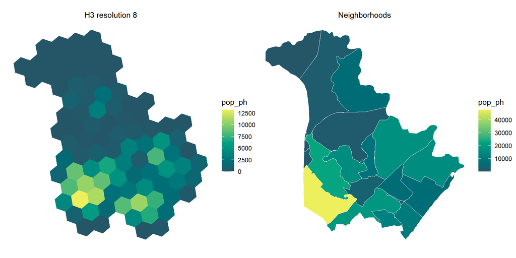

Figure 4: Dasymetric estimates of private-household population (`pop_ph`) for Lauro de Freitas, Bahia, interpolated from 2022 census tract totals to H3 hexagons at resolution~8 (left) and to neighborhoods (right) using CNEFE dwelling points as ancillary data.

The diagnostic summary is displayed at the end of each call, regardless of the `verbose` setting. Running `tracts_to_polygon()` for Lauro de Freitas with `vars = c("pop_ph", "avg_inc_resp")` produces the following report:

```r
poly_diag <- cnefetools::tracts_to_polygon(
  code_muni = 2919207,
  polygon   = nei,
  vars      = c("pop_ph", "avg_inc_resp"),
  verbose   = FALSE
)
```

```
#> ✔ spatial extension loaded
#>
#> ── Dasymetric interpolation diagnostics ──
#>
#> ── Stage 1: Tracts → CNEFE points
#> ! Unallocated total for population from private households (pop_ph):
#>   0 of 202583 (0.00%)
#> ! avg_inc_resp assigned to 95484 of 95515 eligible points (99.97% of
#>   total points)
#> ! avg_inc_resp is NA in 4 of 354 tracts (1.13% of total tracts)
#> ! Unmatched CNEFE points (no tract): 186 of 95739 points (0.19% of
#>   total points)
#> ! Tracts with NA totals: pop_ph in 4 of 354 tracts (1.13% of total
#>   tracts).
#>
#> ── Stage 2: CNEFE points → Polygons
#> ℹ Polygon coverage: 95492 of 95553 allocated points captured (99.94%)
```

Stage 1 of the report describes how completely the census tract totals were allocated to CNEFE dwelling points before aggregation to the target polygons. The unallocated fraction for count variables such as `pop_ph` measures the share of the official population total that could not be distributed because certain tracts contained no eligible CNEFE dwelling points in the matched dataset. For `avg_inc_resp`, the diagnostic additionally reports the number of tracts where the income variable is `NA` in the IBGE source table.

Stage 2 describes how well the user-supplied polygons capture the allocated dwelling points. The coverage percentage is the share of all allocated CNEFE points that fall within at least one of the provided polygons. Values below 100% indicate that some dwelling points lie outside the polygon layer. Polygons with no captured CNEFE points receive zero for all count variables and `NA` for `avg_inc_resp` in the output object.

Users should bear in mind that dasymetric interpolation produces estimates, not observed values. The method assumes that the attribute being redistributed (e.g., population) is distributed proportionally to dwelling points within each census tract. While this is a more realistic assumption than uniform areal weighting, it remains an approximation: if population density varies systematically within a tract in ways not captured by the CNEFE point pattern, the sub-tract estimates will be correspondingly biased. Inferences about individuals or households from these tract-level aggregates are therefore subject to the ecological fallacy (Robinson 1950).

### 4.5 Utility functions

cnefetools also exports five utility functions for documentation access, cache management and data export. `cnefe_dictionary()` opens the official CNEFE data dictionary (an Excel file bundled with the package) in the system’s default spreadsheet viewer, providing column definitions and value codes for all 34 fields of the CNEFE schema. `cnefe_doc()` opens the bundled IBGE methodological note (Instituto Brasileiro de Geografia e Estatística 2024) as a PDF, detailing the geocoding procedures and quality classifications used in the 2022 census.

```r
cnefe_dictionary()  # opens the Excel data dictionary
cnefe_doc()         # opens the IBGE methodological PDF
```

`clear_cache_muni()` deletes cached CNEFE files from the cache directory, either all at once or for a specific municipality identified by its seven-digit IBGE code. `clear_cache_tracts()` removes cached census tract Parquet files, with optional filtering by state, accepting a two-letter UF abbreviation, a two-digit numeric state code, or a seven-digit municipality code (which is resolved to its state automatically).

```r
clear_cache_muni()          # delete all cached CNEFE files
clear_cache_muni(2919207)   # delete only the file for Lauro de Freitas-BA

clear_cache_tracts()        # delete all cached census tract Parquets
clear_cache_tracts("BA")    # delete only the Parquet for the state of Bahia ("BA")
```

`cnefe_export()` writes a municipality to a directory of the user’s choosing as Parquet (the default), CSV or gzipped CSV, so that an analysis can keep its own copy of the data instead of depending on the cache, which the functions above are meant to empty. The `file` argument of `read_cnefe()` reads any of those formats, as well as the ZIP exactly as IBGE publishes it, and skips the download entirely.

```r
# Write Lauro de Freitas-BA to a project folder as Parquet
path <- cnefe_export(2919207, path = "data/cnefe")

# Read it back later without downloading anything
cnefe <- read_cnefe(file = path)
```

## 5 Performance

The DuckDB backend derives its performance advantage from three sources:

1. **In-process execution**: DuckDB runs as a library within the R process, eliminating the overhead of client–server communication.
2. **Streaming aggregation**: DuckDB decompresses the cached gzipped CSV natively, with no extension involved, and aggregates as it scans, so the full address table is never materialised. For São Paulo, this is the difference between holding roughly 5.7 million addresses in memory and holding only the running group totals.
3. **Vectorised query execution**: DuckDB uses a columnar engine with SIMD-accelerated operations, making aggregation and joins over tens of millions of rows substantially faster than row-oriented R operations.

Performance is benchmarked along two independent dimensions. The first varies municipality size (measured by the number of CNEFE address points) while holding the H3 output resolution fixed at 8, using three municipalities of increasing size. The second varies H3 resolution across levels 7, 9, and 11 while holding the municipality fixed at Curitiba-PR. All measurements were collected on a machine with a 14-core Intel Core i9-13900H (2.60 GHz), 32 GB RAM, Windows 11, R 4.6.0, and DuckDB 1.5.2.

Elapsed times drift within a session as the CPU changes thermal and frequency state, by as much as a factor of two, so timing every DuckDB case and then every pure-R case would load that drift onto one backend and make it indistinguishable from the effect being measured. Each configuration is therefore visited once per pass, round-robin, and the pass is repeated three to five times, with every replicate run in a fresh R subprocess after a discarded warm-up. The figures report the median across replicates, and the whiskers show the observed minimum and maximum. Peak memory is the operating system’s peak working set for the whole R process, obtained through the `ps` package rather than R-level allocation tracking, which counts only the R heap and would miss what DuckDB allocates in C++. Figure 5 shows that DuckDB reduces the median elapsed time for `cnefe_counts()` from 4.69 s to 3.79 s for Vitória da Conquista-BA (approximately 200,000 addresses, 1.24× speedup), from 9.19 s to 3.53 s for Curitiba-PR (approximately 900,000 addresses, 2.60× speedup), and from 93.25 s to 5.58 s for São Paulo-SP (approximately 5.7 million addresses, 16.7× speedup). The relative advantage grows with dataset size, because DuckDB’s columnar engine and streaming scan scale more favourably than row-oriented R operations. For small municipalities, the fixed initialisation overhead of opening a connection and loading the H3 extension can dominate and the two backends perform comparably.

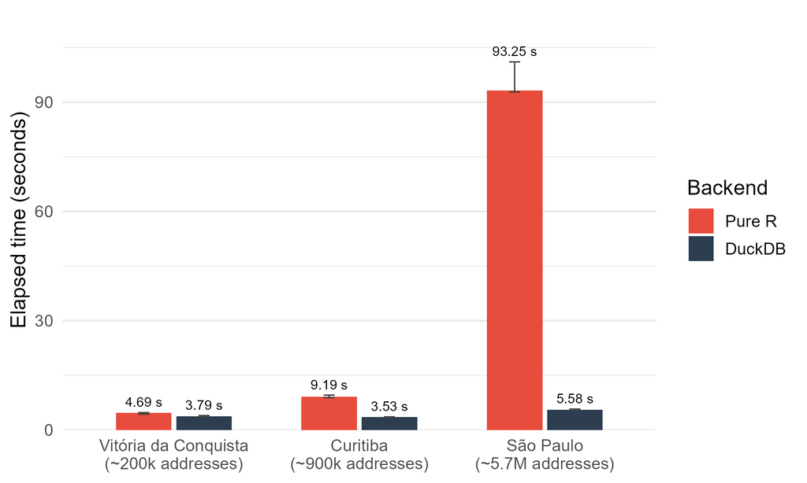

Figure 5: Elapsed time (s) for `cnefe_counts()` at H3 resolution~8, by municipality size, comparing the DuckDB and pure-R backends.

Figure 6 shows results for Curitiba-PR across three H3 resolutions. The DuckDB speedup is 2.17× at resolution 7, 2.39× at resolution 9, and 1.17× at resolution 11. At finer resolutions (higher cell counts), the point-to-cell indexing dominates the total runtime, and both backends ultimately delegate it to the same underlying H3 C library, so the relative DuckDB advantage shrinks.

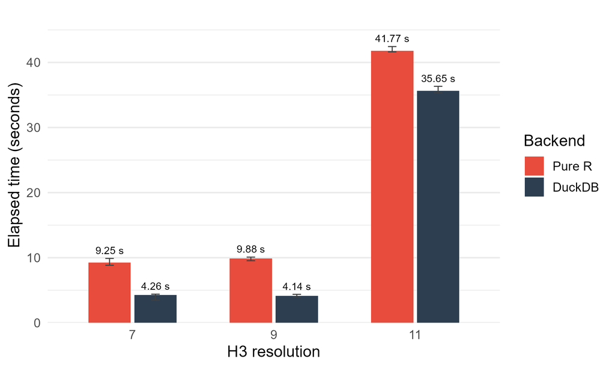

Figure 6: Elapsed time (s) for `cnefe_counts()` on Curitiba-PR, by H3 resolution.

### 5.1 Memory

Figure 7 reports peak memory for the same comparison, and it runs opposite to the intuition that an in-process analytical database is the memory-hungry option. DuckDB stays nearly flat across a 28-fold increase in input, rising only from 0.46 GB on Vitória da Conquista-BA to 0.70 GB on São Paulo-SP, because it streams and aggregates rather than materialising the address table. The pure-R backend holds the filtered table in R memory, so its footprint scales with the input and reaches 9.03 GB on São Paulo-SP, 12.8 times the DuckDB figure.

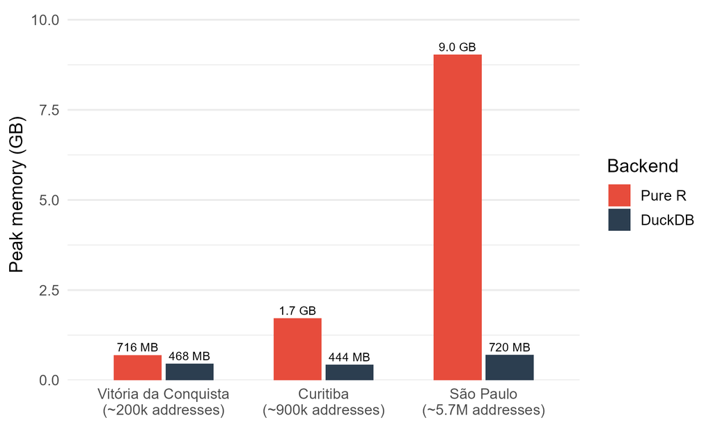

Figure 7: Peak memory (GB) for `cnefe_counts()` at H3 resolution~8, by municipality size, comparing the DuckDB and pure-R backends.

This separates two constraints that were previously treated as one. The pure-R backend is the appropriate choice when DuckDB extensions cannot be installed, such as on some restricted computing clusters, which is the case it was written for, and it is the wrong choice when the binding constraint is memory. DuckDB sets `memory_limit` to 80% of installed RAM by default, so it asks for less on a smaller machine, and a query that exceeds the limit spills to a temporary directory instead of failing. The budget can also be set explicitly:

```r
options(cnefetools.duckdb_config = list(threads = 4, memory_limit = "4GB"))
```

### 5.2 Other heavy functions

`compute_lumi()` performs the same scan, the same H3 assignment and the same grouped aggregation as `cnefe_counts()`, and then adds arithmetic that runs once per output cell rather than once per address, which on São Paulo-SP is roughly four orders of magnitude fewer operations. Measured at H3 resolution 8, the ratio between the two functions stays between 0.95 and 1.19 across all three municipalities and both backends, with no trend in input size, so the indices are effectively free relative to the aggregation that produces them. We report the equivalence rather than plotting the same curve twice.

The dasymetric interpolation functions behave differently and are reported separately in Table 5. They overlay the full CNEFE point set against census tract polygons and download the tract attributes for the whole state, and they run only on DuckDB. Two features are worth noting. Their cost does not track address count: Vitória da Conquista-BA is slower than Curitiba-PR despite being four and a half times smaller, because at that size the runtime is dominated by loading the state’s census tract Parquet file, and Bahia’s is more than twice the size of Paraná’s. In addition, `tracts_to_polygon()` is the most memory-hungry path in the package, reaching 4.28 GB on São Paulo-SP, because an overlay against arbitrary user polygons cannot use the H3 shortcut.

Table 5: Median elapsed time and peak memory for the dasymetric interpolation functions, at H3 resolution 9 on the DuckDB backend.

| Municipality | `tracts_to_h3()` | `tracts_to_polygon()` |
| --- | --- | --- |
| Vitória da Conquista-BA (~200k) | 9.77 s, 0.66 GB | 7.27 s, 0.80 GB |
| Curitiba-PR (~900k) | 6.91 s, 0.61 GB | 5.25 s, 1.09 GB |
| São Paulo-SP (~5.7M) | 15.65 s, 1.93 GB | 15.53 s, 4.28 GB |

### 5.3 Constrained resources

Table 6 reports the largest municipality re-run with DuckDB held to four threads and a 4 GB memory limit, which the `cnefetools.duckdb_config` option makes settable. São Paulo-SP aggregates in about seven seconds within that budget, 26% slower than on the full machine while using 36% less memory, and the dasymetric interpolation costs 34% more time, so neither degrades sharply as the envelope tightens.

Table 6: Median elapsed time and peak memory on São Paulo-SP under a constrained DuckDB configuration, against the same calls with the machine’s full resources.

| São Paulo-SP (~5.7M addresses) | full machine | 4 threads, 4 GB |
| --- | --- | --- |
| `cnefe_counts()` | 5.58 s, 0.70 GB | 7.01 s, 0.45 GB |
| `tracts_to_h3()` | 15.65 s, 1.93 GB | 20.93 s, 1.75 GB |

This shows that the package works within a small resource envelope, but it is not a substitute for measuring on older hardware, since the storage, the RAM speed, the CPU generation and the operating system are all unchanged. A genuinely older machine would do worse, particularly on the initial read, which is bound by input and output rather than by computation and which limiting the thread count does not reproduce. The machine specification is reported above so that readers can scale expectations accordingly.

For most users, the default DuckDB backend is recommended, on both time and memory. The pure-R backend (`backend = "r"`) remains available for environments where DuckDB extensions cannot be installed.

## 6 Summary

cnefetools makes the 2022 Brazilian CNEFE address dataset accessible and analytically useful from R. Its principal contributions are:

1. **Data access**: a pre-built municipality index and persistent caching layer that abstract away the FTP structure and eliminate repeated downloads.
2. **Address aggregation**: flexible aggregation of address counts to H3 hexagonal grids or arbitrary polygons, supporting both a fast DuckDB backend and a portable pure-R fallback.
3. **Land use mix indices**: a complete implementation of six established and novel LUM indices, including the directional, globally referenced BGBI.
4. **Dasymetric interpolation**: tract-to-hexagon and tract-to-polygon redistribution of census variables using CNEFE dwelling points as ancillary data, with per-variable allocation diagnostics.
5. **DuckDB dual-backend**: a performance architecture that streams the cached gzipped CSV, assigns H3 cells and performs spatial joins entirely within an in-process DuckDB engine. Its advantage grows with dataset size, exceeding fifteenfold on the largest municipality, where its peak memory is also more than twelve times smaller than the pure-R backend’s.

The package also has some limitations. First, data access depends on IBGE, and that dependency carries two different risks. The FTP server may be unavailable, which the cache mitigates, since a municipality that has been downloaded once keeps working without a connection. The terms of access may also change, since publishing individual geocoded address points for a whole country is unusually granular for a national statistical product, and a future review could put the CNEFE behind authentication, aggregation or a licence, which no caching strategy can mitigate. What the package offers against that risk is that `read_cnefe(file = ...)` reads a file obtained through another channel without going through the download, although the analytical functions still retrieve their data through the cache and would need the same option to work in that situation. Second, although the package supports aggregation to H3 grids and user-supplied polygons, its core analytical workflows are organised around municipality-specific inputs, which limits analyses that span multiple municipalities or other cross-boundary study regions. Third, the land use mix implementation is restricted to a binary residential versus non-residential formulation, even though the underlying CNEFE classification distinguishes a richer set of address types.

The second limitation matters most for research questions posed at the scale of a metropolitan region. Analyses of that kind are achievable today by iterating the relevant function over a vector of municipality codes and combining the results, and Pedreira Junior (2026) gives a worked example applying exactly that pattern across the 39 municipalities of the São Paulo metropolitan region. Two caveats apply when doing so. The H3 grid built by `cnefe_counts()` and `compute_lumi()` is derived from each municipality’s own boundary, and cells are selected by whether their centre falls inside it, so a cell straddling a shared border belongs to exactly one of the two municipalities and its counts reflect only that municipality’s addresses. The citywide residential share $P$ that `compute_lumi()` uses as its reference is likewise computed per municipality, which is the intended behaviour but means that indices defined against it are not directly comparable across municipalities without recomputing the baseline for the wider area.

The third limitation matters for questions in which the kind of non-residential use is the point. The binary split places agricultural establishments (type 3), which make up 3.7% of all addresses and are qualitatively different from urban uses, in the same group as schools and hospitals, and it merges other-purpose establishments (type 6), a heterogeneous category that includes commerce and services and makes up 10.5% of addresses, with educational, health and religious ones. A study of urban health that needs to separate commercial from institutional uses, for example, cannot do so with these indices. For such questions, the counts returned by `cnefe_counts()` keep all eight address types and can feed a multi-category index directly.

A related design choice concerns what `read_cnefe()` returns. It returns an Arrow table or an `sf` object held in memory, rather than a lazy DuckDB relation that would be evaluated only when queried. A lazy relation is valid only while its database connection is open, so returning one would mean keeping a connection alive after the function returns, whereas every function in the package closes its connection before returning, which guarantees that no connection is left open after an error or an interruption. For a municipality too large to hold in memory comfortably, the better route is to export it to Parquet with `cnefe_export()` and query the file lazily with `arrow::open_dataset()` or DuckDB.

Future development will focus on reducing these constraints. One priority is to provide access to preprocessed remote Parquet assets for CNEFE data, reducing reliance on the IBGE FTP infrastructure and improving robustness and read performance. Another is to further leverage DuckDB’s spatial extension to support arbitrary polygon layers and hexagonal grids that are not restricted to municipal boundaries, while handling the necessary municipal CNEFE files internally. A third direction is to expand the land use mix module with additional indices and formulations that exploit the multi-category structure of CNEFE, moving beyond the current binary residential/non-residential approach.

cnefetools is available on CRAN and its development version on GitHub (https://github.com/pedreirajr/cnefetools). Documentation and pre-rendered vignettes are available at https://pedreirajr.github.io/cnefetools/.

### 6.1 Supplementary materials

Supplementary materials are available in addition to this article. It can be downloaded at cnefetools.zip

### 6.2 CRAN packages used

cnefetools, sf, areal, populR, h3jsr, checkmate, duckdb, duckspatial, piggyback, geobr, censobr, arrow, dplyr, a5R, smile

### 6.3 CRAN Task Views implied by cited packages

Databases, HighPerformanceComputing, MissingData, ModelDeployment, Spatial, SpatioTemporal, WebTechnologies

M. Batsaris and D. Kavroudakis. populR: A package for population downscaling in R. *The R Journal*, 14(4): 223–234, 2023. DOI 10.32614/RJ-2023-007.

C. Boettiger and T. Ho. *piggyback: Managing larger data on a GitHub repository.* 2023. DOI 10.32614/CRAN.package.piggyback. R package version 0.1.5. https://CRAN.R-project.org/package=piggyback.

A. Cidre González, E. Kotov and R. H. M. Pereira. *duckspatial: R interface to ’DuckDB’ database with spatial extension.* 2026. DOI 10.32614/CRAN.package.duckspatial. R package version 1.1.0. https://CRAN.R-project.org/package=duckspatial.

L. da Cunha Godoy. *smile: Spatial misalignment: Interpolation, linkage, and estimation.* 2025. DOI 10.32614/CRAN.package.smile. R package version 1.1.0. https://CRAN.R-project.org/package=smile.

S. J. Dark and D. Bram. The modifiable areal unit problem (MAUP) in physical geography. *Progress in Physical Geography*, 31(5): 471–479, 2007. DOI 10.1177/0309133307083294.

H. Graham. *a5R: ’A5’ discrete global grid system.* 2026. R package version 0.6.0. https://CRAN.R-project.org/package=a5R.

L. Hamilton. *h3jsr: Access Uber’s H3 library.* 2023. R package version 1.3.0. https://CRAN.R-project.org/package=h3jsr.

Instituto Brasileiro de Geografia e Estatística. Censo Demográfico 2022: Coordenadas Geográficas dos Endereços. Nota metodológica n. 01. *Coleção ibgeana*, 26 pages. Rio de Janeiro: Instituto Brasileiro de Geografia e Estatística. 2024. URL https://biblioteca.ibge.gov.br/visualizacao/livros/liv102063.pdf. Accessed: 2026-02-27.

Instituto Brasileiro de Geografia e Estatística. Estimativas da população. 2026. URL https://ftp.ibge.gov.br/Estimativas_de_Populacao/Estimativas_2025/POP2025_20260113.pdf. Accessed: 2026-02-27.

A. Kmoch, K. Sahr, W. T. Chan and E. Uuemaa. IGEO7: A new hierarchically indexed hexagonal equal-area discrete global grid system. *AGILE: GIScience Series*, 6: 1–6, 2025. DOI 10.5194/agile-giss-6-32-2025.

M. Lang. checkmate: Fast argument checks for defensive R programming. *The R Journal*, 9(1): 437–445, 2017. DOI 10.32614/RJ-2017-028.

D. S. Massey. The prodigal paradigm returns: Ecology comes back to sociology. In *Does it take a village? Community effects on children, adolescents, and families*, Eds A. Booth and A. C. Crouter 2001. Mahwah, NJ: Lawrence Erlbaum.

J. Mennis. Generating surface models of population using dasymetric mapping. *The Professional Geographer*, 55(1): 31–42, 2003. DOI 10.1111/0033-0124.10042.

H. Mühleisen and M. Raasveldt. *duckdb: DuckDB database management system.* 2024. R package version 1.1.0. https://CRAN.R-project.org/package=duckdb.

E. Pebesma. Simple features for R: Standardized support for spatial vector data. *The R Journal*, 10(1): 439–446, 2018. DOI 10.32614/RJ-2018-009.

J. U. Pedreira Junior. Dasymetric interpolation from census tracts to traffic zones using cnefetools. 2026. URL https://pedreirajr.github.io/website/posts/2026-02-18-census-tracts-rmsp/. Accessed: 2026-02-27.

J. U. Pedreira Junior, T. V. Louro, L. B. M. de Assis and P. L. Brito. Measuring land use mix with address-level census data. 2025. URL https://engrxiv.org/preprint/view/5975. engrXiv preprint.

J. U. Pedreira Junior, T. V. Louro, L. B. M. de Assis, P. L. Brito and F. G. Bomfim. BGBI: A citywide-referenced and bidirectional land use mix index for planning and policy evaluation. *Land Use Policy*, 169: 108135, 2026. DOI 10.1016/j.landusepol.2026.108135.

R. H. M. Pereira and R. J. Barbosa. censobr: Fácil acesso aos dados dos censos demográficos brasileiros. *Dados*, 69(1): e20240150, 2026. DOI 10.1590/dados.2026.69.1.006.

R. H. M. Pereira, C. N. Gonçalves, et al. geobr: Loads shapefiles of official spatial data sets of Brazil. 2019. URL https://github.com/ipeaGIT/geobr.

C. Prener and C. Revord. Areal: An R package for areal weighted interpolation. *Journal of Open Source Software*, 4(37): 1221, 2019. DOI 10.21105/joss.01221.

M. Raasveldt and H. Mühleisen. DuckDB: An embeddable analytical database. In *Proceedings of the 2019 international conference on management of data*, pages. 1981–1984 2019. ACM. DOI 10.1145/3299869.3320212.

N. Richardson, I. Cook, N. Crane, D. Dunnington, R. François, J. Keane, B. Mecum, D. Moldovan-Grünfeld, J. Ooms, J. Wujciak-Jens, et al. *arrow: Integration to ’Apache’ ’Arrow’.* 2026. DOI 10.32614/CRAN.package.arrow. R package version 24.0.0. https://CRAN.R-project.org/package=arrow.

W. S. Robinson. Ecological correlations and the behavior of individuals. *American Sociological Review*, 15(3): 351–357, 1950. DOI 10.2307/2087176.

Y. Song, L. Merlin and D. Rodriguez. Comparing measures of urban land use mix. *Computers, Environment and Urban Systems*, 42: 1–13, 2013. DOI 10.1016/j.compenvurbsys.2013.08.001.